# NDH802 Solutions to rec. exercises Chap 2 and 3

Huong

## 1.4

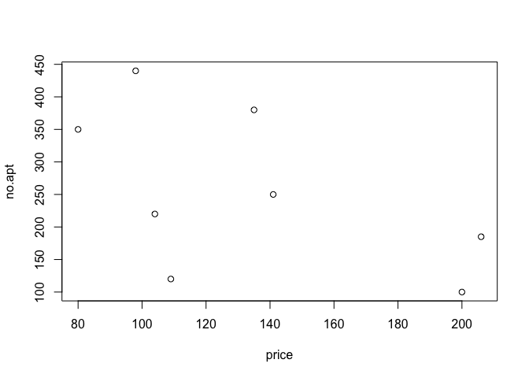

```r
#Data
price = c(104, 135, 80, 200, 98, 206, 141, 109)
no.apt = c(220, 380,350, 100, 440, 185, 250, 120)
plot(price, no.apt)
```

## 2.4

```r
data_q2.4 = c(2.51, 3.74, 4.15, 5.33, 6.18, 6.65, 6.92, 6.95, 7.18, 7.54)
mean(data_q2.4)
```

```
## [1] 5.715
```

```r
median(data_q2.4)
```

```
## [1] 6.415
```

## 2.12

```r
data_q2.12 = c(5, 9, 10, 2, 7, 9, 14)
var(data_q2.12)
```

```
## [1] 14.66667
```

```r
sd(data_q2.12)
```

```
## [1] 3.829708
```

## 2.20

```r
eur_usd = c(1.1410, 1.1363, 1.1351, 1.1324, 1.1276, 1.1332, 1.1266)
usd_jyp = c(109.95, 109.96, 109.80, 109.77, 110.41, 110.48, 110.00)
mean(eur_usd) < mean(usd_jyp)
```

```
## [1] TRUE
```

```r
sd(eur_usd) < sd(usd_jyp)
```

```
## [1] TRUE
```

## 3.7

a.

| Pairs |  |  |  |  |
| --- | --- | --- | --- | --- |
| 1. M1,M2 | 5. M2,M1 | 9. M3,M1 | 13. T1,M1 | 17. T2,M1 |
| 2. M1,M3 | 6. M2,M3 | 10.M3,M2 | 14. T1,M2 | 18. T2,M2 |
| 3. M1,T1 | 7. M2,T1 | 11. M3,T1 | 15. T1,M3 | 19. T2,M3 |
| 4. M1,T2 | 8. M2,T2 | 12. M3,T2 | 16. T1,T2 | 20. T2,T1 |

b. Event A is that at least one of the two cars selected is a Toyota. Outcomes 3, 4, 7, 8, 11-20.

c. Event B is that the two cars selected are of the same model. Outcomes 1, 2, 5, 6, 9, 10, 16, 20.

d. The complement of A is the event that the customers do not select at least one Toyota. That is, no one chose Toyota. Equivalently, both of them chose Mercedes. Outcomes 1, 2, 5, 6, 9, 10.

e. $(A \cap B) \cup (\bar{A} \cap B) = (A \cup \bar{A}) \cap B = B$. Alternatively, we can see:

- $(A \cap B)$: Outcomes 16, 20.
- $(\bar{A} \cap B)$: Outcomes 1, 2, 5, 6, 9, 10.
- $(A \cap B) \cup (\bar{A} \cap B)$: Outcomes 1, 2, 5, 6, 9, 10, 16, or 20; which is event B.

d. $A \cup (\bar{A} \cap B) = (A \cup \bar{A}) \cap (A \cup B) = A \cup B$. Alternatively, we can see:

- $(\bar{A} \cap B)$: Outcomes 1, 2, 5, 6, 9, 10.
- $A \cup (\bar{A} \cap B)$: Outcomes 1-20, which is $A \cup B$.

## 3.19

$$\begin{align*}
P( A \cap B) &= P(A) + P(B) - P(A \cup B) \\ &= 0.3 + 0.7 - 0.9 = 0.1
\end{align*}$$

## 3.98

Assumptions: $P(MBA) = 0.35$, $P(\>35 yo+) = 0.4$, $P(35yo+ \mid MBA) = 0.3$.

```r
P_MBA = 0.35
#for simplicity, let's use this to denote probability of staff who are older than 35
P_35yo = 0.4
P_35yo_given_MBA = 0.3
```

a. $P(MBA \cap 35yo+) = P(35yo+ \mid MBA) * P(MBA)$

```r
P_MBA_intersect_35yo = P_35yo_given_MBA * P_MBA
```

b. $P(MBA \mid 35yo+) = \frac{P(MBA \cap 35yo+)}{P(35yo+)}$

```r
P_MBA_given_35yo = P_MBA_intersect_35yo/P_35yo
```

c. $P(MBA \cup 35yo+) = P(MBA) + P(35yo+) - P(MBA\cap35yo+)$

```r
P_MBA_union_35yo = P_MBA + P_35yo - P_MBA_intersect_35yo
```

d. $P(\bar{MBA} \mid 35yo+) = 1 - P(MBA\mid35yo+)$

```r
P_not_MBA_given_35yo = 1 - P_MBA_given_35yo
```

e. Are the events MBA and over age 35 independent? No, because $P(MBA\cap35yo+) \ne P(MBA)*P(35yo+)$.

f. Are the events MBA and over age 35 mutually exclusive? No, because $P(MBA\cap35yo+) \ne 0$

## 3.108

Let A be the event where the passengers are carrying more liquor than is allowed and B be the event where the TPS identifies it. We have $P(A) = 0.2, P(B \mid A) = 0.8$ and $P(B|\bar{A}) = 0.2$. By Bayes’s theorem:

$$\begin{align*}
P(A \mid B)
& = \frac{P(B \mid A) * P(A)}{P(B)} \\
& = \frac{P(B \mid A)*P(A)}{P(B \mid A)*P(A) + P(B \mid \bar{A})*P(\bar{A})} \\
& = \frac{0.8*0.2}{0.8*0.2 + 0.2*0.8} = 0.5
\end{align*}$$
In case you wonder, this is normally called the law of total probability, which is quite handy:

$$\begin{align*}
P(B) & = P(A \cap B) + P(\bar{A} \cap B) \quad \text{(See Exercise 3.7e)}\\
& = P(B \mid A)*P(A) + P(B \mid \bar{A})*P(\bar{A})
\end{align*}$$